# Lecture 4: Basic cleaning, loops, and alternatives

Spring 2021

## Agenda

- Lists
- A common data cleaning task
- Factor variables, and when they’re useful
- Functions
- If-else statements
- For/while loops to iterate over data
- R coding style
- Rather than picking up where Lecture 3 left off I’ve woven the Lecture 3 content we haven’t yet covered into the Lecture 4 notes

## Package loading

```r
library(tidyverse)
Cars93 <- MASS::Cars93  # For Cars93 data again
```

## Basics of lists

> A list is a **data structure** that can be used to store **different kinds** of data
- Recall: a vector is a data structure for storing *similar kinds of data*
- To better understand the difference, consider the following example.

```r
my.vector.1 <- c("Michael", 165, TRUE)  # (name, weight, is.male)
my.vector.1
```

```
## [1] "Michael" "165"     "TRUE"
```

```r
typeof(my.vector.1)
```

```
## [1] "character"
```

## Lists vs. vectors

```r
my.vector.2 <- c(FALSE, TRUE, 27)  # (is.male, is.citizen)
my.vector.2
```

```
## [1]  0  1 27
```

```r
typeof(my.vector.2)
```

```
## [1] "double"
```

- Vectors expect elements to be all of the same type (e.g., `Boolean`, `numeric`, `character`)
- When data of different types are put into a vector, the R converts everything to a common type

## Lists

- To store data of different types in the same object, we use lists
- Simple way to construct lists: use **`list()`** function
- (We’ll learn about functions like `map` and `map_chr` soon.)

```r
my.list <- list("Michael", 165, TRUE)
my.list
```

```
## [[1]]
## [1] "Michael"
##
## [[2]]
## [1] 165
##
## [[3]]
## [1] TRUE
```

```r
map_chr(my.list, typeof)
```

```
## [1] "character" "double"    "logical"
```

## Named elements

```r
patient.1 <- list(name="Michael", weight = 165, is.male=TRUE)
patient.1
```

```
## $name
## [1] "Michael"
##
## $weight
## [1] 165
##
## $is.male
## [1] TRUE
```

## Referencing elements of a list (similar to data frames)

```r
patient.1$name # get "name" element (returns a string)
```

```
## [1] "Michael"
```

```r
patient.1[["name"]]  # get "name" element (returns a string)
```

```
## [1] "Michael"
```

```r
patient.1["name"]   # get "name" slice (returns a list)
```

```
## $name
## [1] "Michael"
```

```r
c(typeof(patient.1$name), typeof(patient.1["name"]))
```

```
## [1] "character" "list"
```

## A common problem

- One of the most common problems you’ll encounter when importing manually-entered data is inconsistent data types within columns
- For a simple example, let’s look at `TVhours` column in a messy version of the survey data from Lecture 2

```r
#survey.messy <- read.csv('/Users/osita/OneDrive/Desktop/STAT 2600 SPRING 2021/Coding/survey_data2020_messy.csv',
#                         header=TRUE, stringsAsFactors = FALSE)


survey.messy <- read.csv("https://www.colorado.edu/amath/sites/default/files/attached-files/survey_data2020_messy.txt", sep = "\t")  # use sep = "\t" when you save your file as .txt tab delimited


survey.messy
```

```
##    Program                PriorExp          Rexperience OperatingSystem
## 1      PPM         Some experience           Never used         Windows
## 2    Other    Extensive experience     Basic competence        Mac OS X
## 3     MISM Never programmed before     Basic competence         Windows
## 4      PPM Never programmed before           Never used         Windows
## 5      PPM Never programmed before           Never used         Windows
## 6      PPM         Some experience     Basic competence        Mac OS X
## 7      PPM Never programmed before           Never used        Mac OS X
## 8      PPM         Some experience Installed on machine        Mac OS X
## 9      PPM         Some experience     Basic competence         Windows
## 10   Other         Some experience     Basic competence         Windows
## 11     PPM Never programmed before           Never used         Windows
## 12     PPM    Extensive experience           Never used      Linux/Unix
## 13     PPM    Extensive experience     Basic competence        Mac OS X
## 14     PPM         Some experience     Basic competence         Windows
```

[output cut: 101 more lines]

```r
# Print out first 20 elements
head(survey.messy$TVhours, 20)
```

```
##  [1] "10.5"  "3"     "0"     "10"    "~4"    "0"     "2"     "20ish" "4"
## [10] "0"     "15"    "5"     ">20"   "10"    "5"     "2"     "14"    "10"
## [19] "4"     "3"
```

## What’s happening?

```r
str(survey.messy)
```

```
## 'data.frame':    57 obs. of  6 variables:
##  $ Program        : chr  "PPM" "Other" "MISM" "PPM" ...
##  $ PriorExp       : chr  "Some experience" "Extensive experience" "Never programmed before" "Never programmed before" ...
##  $ Rexperience    : chr  "Never used" "Basic competence" "Basic competence" "Never used" ...
##  $ OperatingSystem: chr  "Windows" "Mac OS X" "Windows" "Windows" ...
##  $ TVhours        : chr  "10.5" "3" "0" "10" ...
##  $ Editor         : chr  "Other" "Microsoft Word" "Microsoft Word" "Excel" ...
```

- Several of the entries have non-numeric values in them (they contain strings)
- As a result, `TVhours` is being imported as `character` vector

## A look at the TVhours column

```r
survey.messy$TVhours
```

```
##  [1] "10.5"      "3"         "0"         "10"        "~4"        "0"
##  [7] "2"         "20ish"     "4"         "0"         "15"        "5"
## [13] ">20"       "10"        "5"         "2"         "14"        "10"
## [19] "4"         "3"         "6"         ">10"       "2"         "3"
## [25] "3"         "1"         "<1"        "3"         "5"         "10"
## [31] "20"        "none"      "9"         "3"         "4"         "8"
## [37] "7"         "8"         "10"        "10"        "4"         "10"
## [43] "4"         "0"         "1"         "7"         "2"         "15"
## [49] "8"         "10"        "2"         "3"         "4"         "21"
## [55] "10"        "approx 20" "0"
```

## Partial fix

- In Lecture 1 we saw that there exists a family of `as.`*type* functions that will try to move objects from one data type to the specified *type*
- We want TVhours to be numeric, so let’s try `as.numeric`

```r
as.numeric(survey.messy$TVhours)
```

```
##  [1] 10.5  3.0  0.0 10.0   NA  0.0  2.0   NA  4.0  0.0 15.0  5.0   NA 10.0  5.0
## [16]  2.0 14.0 10.0  4.0  3.0  6.0   NA  2.0  3.0  3.0  1.0   NA  3.0  5.0 10.0
## [31] 20.0   NA  9.0  3.0  4.0  8.0  7.0  8.0 10.0 10.0  4.0 10.0  4.0  0.0  1.0
## [46]  7.0  2.0 15.0  8.0 10.0  2.0  3.0  4.0 21.0 10.0   NA  0.0
```

## We can do a bit better

```r
as.numeric(survey.messy$TVhours)
```

```
##  [1] 10.5  3.0  0.0 10.0   NA  0.0  2.0   NA  4.0  0.0 15.0  5.0   NA 10.0  5.0
## [16]  2.0 14.0 10.0  4.0  3.0  6.0   NA  2.0  3.0  3.0  1.0   NA  3.0  5.0 10.0
## [31] 20.0   NA  9.0  3.0  4.0  8.0  7.0  8.0 10.0 10.0  4.0 10.0  4.0  0.0  1.0
## [46]  7.0  2.0 15.0  8.0 10.0  2.0  3.0  4.0 21.0 10.0   NA  0.0
```

- All the corrupted cells now appear as `NA`, which is R’s missing indicator
- We can do a little better by looking at the corrupted entries and seeing if we can recover more information from the cells that contained non-numeric values

## Deleting non-numeric (or .) characters

- Here we’ll use the **`gsub()`** function (global substitution) to clean up more of the corruption

```r
#head(survey.messy$TVhours,40)

# Use gsub() to replace everything except digits and '.' with a blank ""

gsub("[^0-9.]", "", survey.messy$TVhours)
```

```
##  [1] "10.5" "3"    "0"    "10"   "4"    "0"    "2"    "20"   "4"    "0"
## [11] "15"   "5"    "20"   "10"   "5"    "2"    "14"   "10"   "4"    "3"
## [21] "6"    "10"   "2"    "3"    "3"    "1"    "1"    "3"    "5"    "10"
## [31] "20"   ""     "9"    "3"    "4"    "8"    "7"    "8"    "10"   "10"
## [41] "4"    "10"   "4"    "0"    "1"    "7"    "2"    "15"   "8"    "10"
## [51] "2"    "3"    "4"    "21"   "10"   "20"   "0"
```

- As a last step, we should go through and figure out if any of the `NA` values should really be `0`.
  - This step is not shown here. You can do that in your spare time to verify.

## One-line cleanup

- Let’s clean up the `TVhours` column and cast it to numeric all in one command

```r
survey.messy <- read.csv("https://www.colorado.edu/amath/sites/default/files/attached-files/survey_data2020_messy.txt", sep = "\t")  # use sep = "\t" when you save your file as .txt tab delimited


survey <- mutate(survey.messy,
                TVhours = as.numeric(gsub("[^0-9.]", "", TVhours)))
str(survey)
```

```
## 'data.frame':    57 obs. of  6 variables:
##  $ Program        : chr  "PPM" "Other" "MISM" "PPM" ...
##  $ PriorExp       : chr  "Some experience" "Extensive experience" "Never programmed before" "Never programmed before" ...
##  $ Rexperience    : chr  "Never used" "Basic competence" "Basic competence" "Never used" ...
##  $ OperatingSystem: chr  "Windows" "Mac OS X" "Windows" "Windows" ...
##  $ TVhours        : num  10.5 3 0 10 4 0 2 20 4 0 ...
##  $ Editor         : chr  "Other" "Microsoft Word" "Microsoft Word" "Excel" ...
```

## Another common problem

- On Homework 2 you’ll learn how to wrangle with another common problem
- When data is entered manually, misspellings and case changes are very common
- E.g., a column showing Program information may look like,

```r
program <- c("ppm", "PPM", "MISM", "HCA", "hca", "mism", "PPM-DA", "MSHCA", "MSPMM-DA", "PPM")

table(program)
```

```
## program
##      hca      HCA     mism     MISM    MSHCA MSPMM-DA      ppm      PPM
##        1        1        1        1        1        1        1        2
##   PPM-DA
##        1
```

```r
table(program)
```

```
## program
##      hca      HCA     mism     MISM    MSHCA MSPMM-DA      ppm      PPM
##        1        1        1        1        1        1        1        2
##   PPM-DA
##        1
```

- This vector has a lot of redundant unique values that we won’t want to carry through our entire analysis
- E.g., hca and HCA, mism and MISM, ppm and PPM should certainly be combined. We might even want to combine PPM and PPM-DA together.
- On HW 2 you’ll see a quick way to fix capitalization issues. For other forms of redundancy, you’ll likely want to use a function like `recode()` introduced in Lecture 3.

## When are factor variables useful?

- Factor variables are handy when it’s important to have control over the ordering of the variable values.
- E.g., What happens when we plot everyone’s prior programming experience?

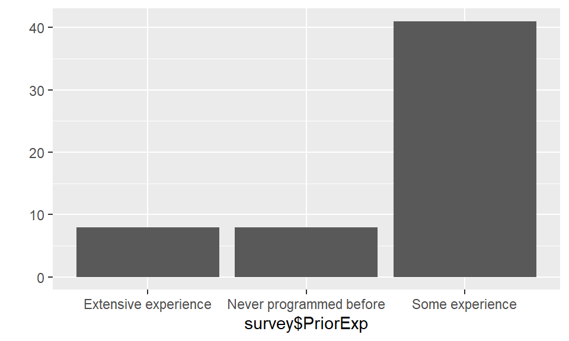

```r
qplot(survey$PriorExp)
```

- The x-axis values appear in alphabetical order. Not always desirable.
- What if we wanted the values to appear in ascending order of experience?

## Factor variables

- We can mutate `PriorExp` into a factor with levels in a specified order using the `factor()` command, specifying the `levels` of the variable in the order we want them to appear

```r
survey <- survey %>%
         mutate(PriorExp = factor(PriorExp,
                              levels = c("Never programmed before",
                                         "Some experience",
                                         "Extensive experience")))
head(survey$PriorExp)
```

```
## [1] Some experience         Extensive experience    Never programmed before
## [4] Never programmed before Never programmed before Some experience
## Levels: Never programmed before Some experience Extensive experience
```

- Now `PriorExp` is a factor variable, with values ordered from “Never programmed before” to “Extensive experience”

## Reconstructing the plot

- Here’s what we get if we run the exact same plotting command again

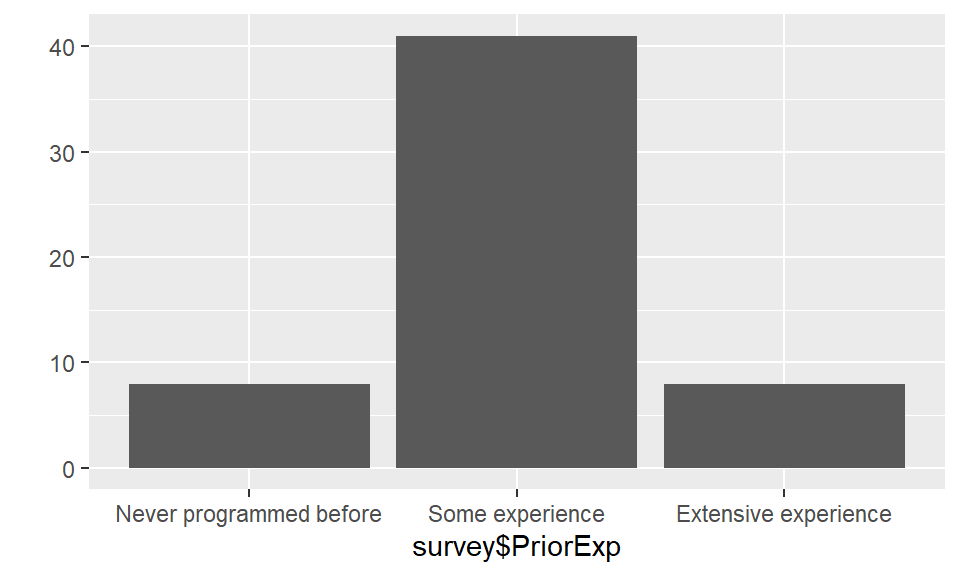

```r
qplot(survey$PriorExp)
```

- Better! This more clearly communicates the distribution of prior programming experience among survey respondents.

## Functions

- We have used a lot of built-in functions: `mean()`, `subset()`, `plot()`, `read.table()`…
- An important part of programming and data analysis is to write custom functions
- Functions help make code **modular**
- Functions make debugging easier
- Remember: this entire class is about applying *functions* to *data*

## What is a function?

> A function is a machine that turns **input objects** (arguments) into an **output object** (return value) according to a definite rule.
- Let’s look at a really simple function

```r
addOne <- function(x){
  x+1}
```

- `x` is the **argument** or **input**
- The function **output** is the input `x` incremented by 1

```r
addOne(12)
```

```
## [1] 13
```

## More interesting example

- Here’s a function that returns a % given a numerator, denominator, and desired number of decimal values

```r
calculatePercentage<- function(x , y, d) {
  decimal<- x/y      #Calculate a decimal value
  round(100* decimal, d)   # convert to % and round to d digits
}

calculatePercentage(27,80,1)
```

```
## [1] 33.8
```

- If you’re calculating several %’s for your report, you should use this kind of function instead of repeatedly copying and pasting code

## `return()`

- In the previous examples we specified the output simply by writing the output variable as the last line of the function
- More explicitly, we can use the **`return()`** function
- We will generally avoid the `return()` function, but you can use it if necessary or if it makes writing a particular function easier.
- Google’s style guide suggests explicit returns. Most do not.

## More programming basics: loops

- We’ll now learn about loops and some more efficient/syntactically simple loop alternatives
- **loops** are ways of iterating over data

## For loops: a pair of examples

```r
for(i in 1:4)
{print(i)}
```

```
## [1] 1
## [1] 2
## [1] 3
## [1] 4
```

```r
phrase<- "Good Night,"
for(word in c("and", "Good" , "Luck")) {
    phrase <- paste(phrase, word)
print(phrase)
}
```

```
## [1] "Good Night, and"
## [1] "Good Night, and Good"
## [1] "Good Night, and Good Luck"
```

## For loops: syntax

> A **for loop** executes a chunk of code for every value of an **index variable** in an **index set**
- The basic syntax takes the form

```r
for(index.variable in index.set) {
  code to be repeated at every value of index.variable
  }
```

- The index set is often a vector of integers, but can be more general

## Example

```r
index.set <- list(name ="Michael", weight=185, is.male=TRUE)   # a list
for (i in index.set) {
  print(c(i, typeof(i)))
}
```

```
## [1] "Michael"   "character"
## [1] "185"    "double"
## [1] "TRUE"    "logical"
```

## Example: Calculate sum of each column

```r
fake.data <- matrix(rnorm(500), ncol=5)  # create fake 100 x 5 data set
head(fake.data, 2)    # print the first two rows
```

```
##            [,1]       [,2]      [,3]      [,4]       [,5]
## [1,] -1.4234086 -0.5244855 1.0884290 0.7334150 -0.3486632
## [2,] -0.2048298 -1.2889189 0.1779175 0.5821432  1.6301151
```

```r
col.sums<- numeric(ncol(fake.data))  # variable to store running colums
for (i in 1:nrow(fake.data)) {
  col.sums<- col.sums + fake.data[i,]  # add ith observation to the sum

}

col.sums
```

```
## [1]  -7.800977 -15.480424   1.326144   7.616057 -12.890283
```

```r
colSums(fake.data)    # A better appraoch (see also colMeans(())
```

```
## [1]  -7.800977 -15.480424   1.326144   7.616057 -12.890283
```

## while loops

- **while loops** repeat a chunk of code while the specified condition remains true

```r
day <- 1
num.days <- 365
while(day <= num.days) {

  day <- day +1
}
day
```

```
## [1] 366
```

- We won’t really be using while loops in this class
- Just be aware that they exist, and that they may become useful to you at some point in your analytics career

## Loop alternatives

| Command | Description |
| --- | --- |
| `apply(X, MARGIN, FUN)` | Obtain a vector/array/list by applying `FUN` along the specified `MARGIN` of an array or matrix `X` |
| `map(.x, .f, ...)` | Obtain a *list* by applying `.f` to every element of a list or atomic vector `.x` |
| `map_<type>(.x, .f, ...)` | For `<type>` given by `lgl` (logical), `int` (integer), `dbl` (double) or `chr` (character), return a *vector* of this type obtained by applying `.f` to each element of `.x` |
| `map_at(.x, .at, .f)` | Obtain a *list* by applying `.f` to the elements of `.x` specified by name or index given in `.at` |
| `map_if(.x, .p, .f)` | Obtain a *list* `.f` to the elements of `.x` specified by `.p` (a predicate function, or a logical vector) |
| `mutate_all/_at/_if` | Mutate all variables, specified (at) variables, or those selected by a predicate (if) |
| `summarize_all/_at/_if` | Summarize all variables, specified variables, or those selected by a predicate (if) |

- These take practice to get used to, but make analysis easier to debug and less prone to error when used effectively
- The best way to learn them is by looking at a bunch of examples. The end of each help file contains some examples.

## Example: apply()

```r
# Start here 02/15/2021
colMeans(fake.data)
```

```
## [1] -0.07800977 -0.15480424  0.01326144  0.07616057 -0.12890283
```

```r
apply(fake.data, MARGIN =2, FUN=mean)  # MARGIN =1 for rows, 2 for columns
```

```
## [1] -0.07800977 -0.15480424  0.01326144  0.07616057 -0.12890283
```

```r
# use functions that calculate proportions of vector indexes that are > 0
propPositive <- function(x)  mean(x>0)
apply(fake.data, MARGIN=2, FUN=propPositive)
```

```
## [1] 0.49 0.43 0.51 0.55 0.47
```

## Example: map, map_()

```r
#map(survey, is.numeric)  # Return a list

map_lgl(survey, is.numeric)  # return a logical vector with named elements
```

```
##         Program        PriorExp     Rexperience OperatingSystem         TVhours
##           FALSE           FALSE           FALSE           FALSE            TRUE
##          Editor
##           FALSE
```

## Example: apply(), map(), map_()

```r
#apply(cars, 2, FUN=mean)  # Data frames are arrays
apply(cars, 2, FUN=mean)
```

```
## speed  dist
## 15.40 42.98
```

```r
#map(cars, mean)  # Data frames are also lists


map_dbl(cars, mean) # map output as a double vector
```

```
## speed  dist
## 15.40 42.98
```

## Example: mutate_if

Let’s convert all factor variables in Cars93 to lowercase

```r
head(Cars93$Type)
```

```
## [1] Small   Midsize Compact Midsize Midsize Midsize
## Levels: Compact Large Midsize Small Sporty Van
```

```r
Cars93.lower<- mutate_if(Cars93, is.factor, tolower)

head(Cars93.lower$Type)
```

```
## [1] "small"   "midsize" "compact" "midsize" "midsize" "midsize"
```

- Note: this has the effect of producing a copy of the `Cars93` data where all of the factor variables have been replaced with versions containing lowercase values

## Example: mutate_if, adding instead of replacing columns

If you pass the functions in as a list with named elements, those names get appended to create modified versions of variables instead of replacing existing variables

```r
Cars93.lower <- mutate_if(Cars93, is.factor, list(lower=tolower))
#head(Cars93.lower$Type)
head(Cars93.lower$Type_lower)
```

```
## [1] "small"   "midsize" "compact" "midsize" "midsize" "midsize"
```

## Example: mutate_at

Let’s convert from MPG to KPML but this time using `mutate_at`

```r
Cars93.metric <- Cars93 %>%
   mutate_at(c("MPG.city", "MPG.highway"), list(KMPL =  ~ 0.425*.x))
tail(colnames(Cars93.metric))
```

```
## [1] "Luggage.room"     "Weight"           "Origin"           "Make"
## [5] "MPG.city_KMPL"    "MPG.highway_KMPL"
```

Here, `~ 0.425 * .x` is an example of specifying a “lambda” (anonymous) function. It is permitted short-hand for

```r
function(.x){0.425*.x}
```

## Example: summarize_if

Let’s get the mean of every numeric column in Cars93

```r
#Cars93 %>% summarize_if(is.numeric, mean)

Cars93 %>% summarize_if(is.numeric, list(mean=mean), na.rm=TRUE)
```

```
##   Min.Price_mean Price_mean Max.Price_mean MPG.city_mean MPG.highway_mean
## 1       17.12581   19.50968       21.89892      22.36559         29.08602
##   EngineSize_mean Horsepower_mean RPM_mean Rev.per.mile_mean
## 1        2.667742         143.828 5280.645          2332.204
##   Fuel.tank.capacity_mean Passengers_mean Length_mean Wheelbase_mean Width_mean
## 1                16.66452        5.086022    183.2043       103.9462   69.37634
##   Turn.circle_mean Rear.seat.room_mean Luggage.room_mean Weight_mean
## 1         38.95699            27.82967          13.89024    3072.903
```

## Example: summarize_at

Let’s get the average fuel economy of all vehicles, grouped by their Type

```r
Cars93 %>% group_by(Type) %>%
  summarize_at(c("MPG.city", "MPG.highway"), mean)
```

```
## # A tibble: 6 x 3
##   Type    MPG.city MPG.highway
## * <fct>      <dbl>       <dbl>
## 1 Compact     22.7        29.9
## 2 Large       18.4        26.7
## 3 Midsize     19.5        26.7
## 4 Small       29.9        35.5
## 5 Sporty      21.8        28.8
## 6 Van         17          21.9
```

## Another approach

We’ll learn about a bunch of select helper functions like `contains()` and `starts_with()`.

Here’s one way of performing the previous operation with the help of these functions, and appending `_mean` to the resulting output.

```r
Cars93 %>%
  group_by(Type) %>%
    summarize_at(vars(contains("MPG")),  list(mean=mean))
```

```
## # A tibble: 6 x 3
##   Type    MPG.city_mean MPG.highway_mean
## * <fct>           <dbl>            <dbl>
## 1 Compact          22.7             29.9
## 2 Large            18.4             26.7
## 3 Midsize          19.5             26.7
## 4 Small            29.9             35.5
## 5 Sporty           21.8             28.8
## 6 Van              17               21.9
```

## More than one grouping variable

```r
Cars93 %>%
  group_by(Origin, AirBags) %>%
  summarize_at(vars(contains("MPG")), list(mean=mean))
```

```
## # A tibble: 6 x 4
## # Groups:   Origin [2]
##   Origin  AirBags            MPG.city_mean MPG.highway_mean
##   <fct>   <fct>                      <dbl>            <dbl>
## 1 USA     Driver & Passenger          19               27.2
## 2 USA     Driver only                 20.2             27.5
## 3 USA     None                        23.1             29.6
## 4 non-USA Driver & Passenger          20.3             27
## 5 non-USA Driver only                 23.2             29.4
## 6 non-USA None                        25.9             32
```